# txy21_3_Tucker_decomposition_and_applications

```python
%load_ext autoreload
%autoreload 2
%matplotlib inline
```

```python
import numpy as np
import matplotlib.pyplot as plt
from hottbox.core import Tensor, TensorTKD
from hottbox.algorithms.decomposition import HOSVD, HOOI
from hottbox.utils.generation import residual_tensor
from coursework.data import get_image, plot_tensors
```

```python
np.random.seed(0)
```

Return to Table of Contents

# Multi-linear rank

The **multi-linear rank** of a tensor $\mathbf{\underline{X}} \in \mathbb{R}^{I_1 \times \cdots \times I_N}$ is the $N$-tuple $(R_1, \dots, R_N)$ where each $R_n$ is the rank of the subspace spanned by mode-$n$ fibers, i.e. $R_n = \text{rank} \big( \mathbf{X}_{(n)} \big)$. Thus, for our order-$3$ tensor the multi-linear rank is $(R_1, R_2, R_3)$. Multi-linear rank provides flexibility in compression and approximation of the original tensor.

> **NOTE:** For a tensor of order $N$ the values $R_1, R_2, \dots , R_N$ are not necessarily the same, whereas, for matrices (tensors of order 2) the equality $R_1 = R_2$ always holds, where $R_1$ and $R_2$ are the matrix column rank and row rank respectively.

# Performing tensor decomposition

```python
# Create tensor
I, J, K = 5, 6, 7
array_3d = np.random.rand(I * J * K).reshape((I, J, K)).astype(float)
tensor = Tensor(array_3d)

# Initialise algorithm
algorithm = HOSVD()

# Perform decomposing for selected multi-linear rank
ml_rank = (4, 5, 6)
tensor_tkd = algorithm.decompose(tensor, ml_rank)

# Result preview
print(tensor_tkd)

print('\n\tFactor matrices')
for mode, fmat in enumerate(tensor_tkd.fmat):
    print('Mode-{} factor matrix is of shape {}'.format(mode, fmat.shape))

print('\n\tCore tensor')
print(tensor_tkd.core)
```

```
Tucker representation of a tensor with multi-linear rank=(4, 5, 6).
Factor matrices represent properties: ['mode-0', 'mode-1', 'mode-2']
With corresponding latent components described by (5, 6, 7) features respectively.

	Factor matrices
Mode-0 factor matrix is of shape (5, 4)
Mode-1 factor matrix is of shape (6, 5)
Mode-2 factor matrix is of shape (7, 6)

	Core tensor
This tensor is of order 3 and consists of 120 elements.
Sizes and names of its modes are (4, 5, 6) and ['mode-0', 'mode-1', 'mode-2'] respectively.
```

# Evaluation and reconstruction

Tucker representation of an original tensor is almost always an approximation, regardless of which algorithm has been employed for performing decomposition. Thus, relative error of approximation is commonly used in order to evaluate performance of computational methods, i.e. the ratio between a Frobenious norms of residual and original tensors.

```python
# Compute residual tensor
tensor_res = residual_tensor(tensor, tensor_tkd)

# Compute error of approximation
rel_error = tensor_res.frob_norm / tensor.frob_norm

print("Relative error of approximation = {}".format(rel_error))
```

```
Relative error of approximation = 0.21320264561618074
```

## **Assigment 1**

1. Create a tensor of order 4 with sizes of each mode being defined by prime numbers and obtain a Tucker representation using HOOI algorithm with multi-linear (4, 10, 6, 2). Then calculation ratio between the number of elements in the original tensor and its Tucker form.
2. For a tensor that consists of 1331 elements, which multi-linear rank guarantees a perfect reconstruction from its Tucker form and why. Is such choice reasonable for practical applications?

### Solution: Part 1

```python
# Create a tensor
I, J, K, L = 2, 3, 5, 7
array_4d = np.random.rand(I * J * K * L).reshape((I, J, K, L)).astype(float)
tensor = Tensor(array_4d)
```

```python
# Perform decomposition

# Initialise algorithm
algorithm = HOSVD()

# Perform decomposing for selected multi-linear rank
ml_rank = (4, 10, 6, 2)
tensor_tkd = algorithm.decompose(tensor, ml_rank)

# Result preview
print(tensor_tkd)

print('\n\tFactor matrices')
for mode, fmat in enumerate(tensor_tkd.fmat):
    print('Mode-{} factor matrix is of shape {}'.format(mode, fmat.shape))

print('\n\tCore tensor')
print(tensor_tkd.core)
```

```
Tucker representation of a tensor with multi-linear rank=(2, 3, 5, 2).
Factor matrices represent properties: ['mode-0', 'mode-1', 'mode-2', 'mode-3']
With corresponding latent components described by (2, 3, 5, 7) features respectively.

	Factor matrices
Mode-0 factor matrix is of shape (2, 2)
Mode-1 factor matrix is of shape (3, 3)
Mode-2 factor matrix is of shape (5, 5)
Mode-3 factor matrix is of shape (7, 2)

	Core tensor
This tensor is of order 4 and consists of 60 elements.
Sizes and names of its modes are (2, 3, 5, 2) and ['mode-0', 'mode-1', 'mode-2', 'mode-3'] respectively.
```

```python
# Print ratio
# Compute residual tensor
tensor_res = residual_tensor(tensor, tensor_tkd)

# Compute error of approximation
rel_error = tensor_res.frob_norm / tensor.frob_norm

print("Relative error of approximation = {}".format(rel_error))

# Compute no. elements in tensor
tensorElements =  tensor.size
# Compute no. elements in core tensor
coreElements = tensor_tkd.core.size
# Compute total no. elements across factor
factElements = 0

for i in range(np.shape(ml_rank)[0]):

    factElements += (np.shape(tensor_tkd.fmat[i])[0] * np.shape(tensor_tkd.fmat[i])[1])

tuckerElements =  factElements + coreElements
finalRatio = tensorElements/tuckerElements

print("Ratio between the number of elements in the original tensor and its Tucker form = {}".format(finalRatio))
```

```
Relative error of approximation = 0.38871898964218055
Ratio between the number of elements in the original tensor and its Tucker form = 1.875
```

### Solution: Part 2

After decomposing 1331 elements into the prime factors (which creates the order of the core tensor of 3): 1331 = 11 x 11 x 11. For a perfect Tucker decomposition, the multi-linear ranks must exactly match the original tensor's dimensions. So the multi-linear rank is (11,11,11). This is because when ranks equal original dimensions, the core tensor becomes a full tensor where no compression or approximation occurs. The decomposition becomes just an identity transformation. However this defeats the primary purpose of tensor decomposition, where dimensionality reduction is desired.

# Application: Image compression

Color images can be naturally represented as a tensor of order three with the shape `(height x width x channels)` where channels are, for example, Red, Blue and Green (RGB)

[figure not shown]

By keeping its original structure, allows to apply methods from multi-linear analysis. For instance, we can employ algorithms for Tucker decompositions in order to commress oringinal informaiton by varying values of desired multi-linear rank.

```
# Get data in form of a Tensor
car = get_image(item="car", view="top")
tensor = Tensor(car)

# Initialise algorithm and preform decomposition
algorithm = HOSVD()
tensor_tkd = algorithm.decompose(tensor, rank=(25, 25, 3))

# Evaluate result
tensor_res = residual_tensor(tensor, tensor_tkd)
rel_error = tensor_res.frob_norm / tensor.frob_norm

print("Relative error of approximation = {}".format(rel_error))
```

When can also visually inspect image obtained by reconstructing the Tucker representation

```
# Reconstruction
tensor_rec = tensor_tkd.reconstruct()

# Plot original and reconstructed images side by side
plot_tensors(tensor, tensor_rec)
```

[figure not shown]

## **Assigment 2**

For this assignment you are provided with function `get_image()` which requires two parameters: `item` and `view`. The valid values for former are **car** and **apple**, while the latter takes only **side** and **top**.

1. Use multi-linear rank equal to `(50, 50, 2)` in order to obtain Tucker representations of images of the car and apple. Analyse results by visually inspecting their reconstructions.
2. Use multi-linear rank equal to `(50, 50, 2)` in order to obtain Tucker representations of images of the apple taken from the top and from the side. Analyse results by visually inspecting their reconstructions.
3. What would happen to the reconstruction if the value of multi-linear rank corresponding to the channel mode is decreased to 1.

### Solution: Part 1

```python
# Create tensors from images
# car
car = get_image(item="car", view="top")
tensorCar = Tensor(car)
print(tensorCar)
# apple
apple =  get_image(item="apple",view="top")
tensorApple = Tensor(apple)
print(tensorApple)
```

```
This tensor is of order 3 and consists of 49152 elements.
Sizes and names of its modes are (128, 128, 3) and ['mode-0', 'mode-1', 'mode-2'] respectively.
This tensor is of order 3 and consists of 49152 elements.
Sizes and names of its modes are (128, 128, 3) and ['mode-0', 'mode-1', 'mode-2'] respectively.
```

```python
# Perform decomposition
algorithm = HOSVD()
tensor_tkdCar = algorithm.decompose(tensorCar, rank=(50, 50, 2))

algorithm = HOSVD()
tensor_tkdApple = algorithm.decompose(tensorApple, rank=(50, 50, 2))
```

```
Relative error of approximation for Car tensor = 0.08950050920521838
Relative error of approximation for Apple tensor = 0.08277558463233738
```

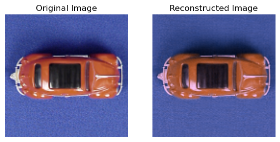

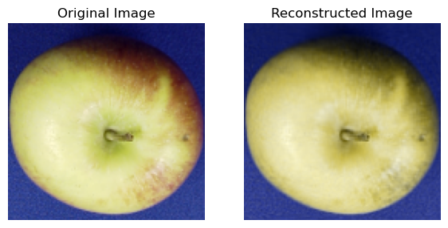

```python
# Evaluate results
# Compute residual tensor
tensor_res = residual_tensor(tensorCar, tensor_tkdCar)
# Compute error of approximation
rel_error = tensor_res.frob_norm / tensorCar.frob_norm
print("Relative error of approximation for Car tensor = {}".format(rel_error))

# Reconstruction
tensor_recCar = tensor_tkdCar.reconstruct()
# Plot original and reconstructed images side by side
plot_tensors(tensorCar, tensor_recCar)


# Compute residual tensor
tensor_res = residual_tensor(tensorApple, tensor_tkdApple)
# Compute error of approximation
rel_error = tensor_res.frob_norm / tensorApple.frob_norm
print("Relative error of approximation for Apple tensor = {}".format(rel_error))
# Reconstruction
tensor_recApple = tensor_tkdApple.reconstruct()
# Plot original and reconstructed images side by side
plot_tensors(tensorApple, tensor_recApple)
plt.show()
```

Reducing the multiplinear rank $R_3$ in the core tensor $G$ to 2 results in 2 dimensions to represent the information for colour. Hence the Tucker decomposition choses two of the most important colours used to represent the image. In the case for the car, green (the least dominant colour) is greatly attenuated, resulting in an image made out of red hues for the car. For the apple, red (green is more dominant than red) is greatly attenuated and the apple is coloured with shades of green instead.

### Solution: Part 2

```python
# Create tensors from images
# appletop
appletop = get_image(item="apple", view="top")
tensorAppletop = Tensor(appletop)
print(tensorCar)
# appleside
appleside =  get_image(item="apple",view="side")
tensorAppleside = Tensor(appleside)
print(tensorApple)
```

```
This tensor is of order 3 and consists of 49152 elements.
Sizes and names of its modes are (128, 128, 3) and ['mode-0', 'mode-1', 'mode-2'] respectively.
This tensor is of order 3 and consists of 49152 elements.
Sizes and names of its modes are (128, 128, 3) and ['mode-0', 'mode-1', 'mode-2'] respectively.
```

```python
# Perform decomposition
algorithm = HOSVD()
tensor_tkdAppletop = algorithm.decompose(tensorAppletop, rank=(50, 50, 2))

algorithm = HOSVD()
tensor_tkdAppleside = algorithm.decompose(tensorAppleside, rank=(50, 50, 2))
```

[output not shown]

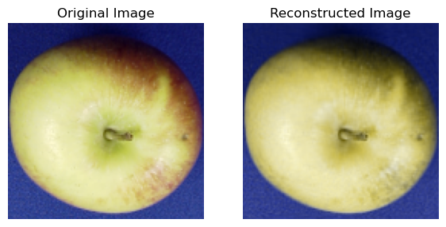

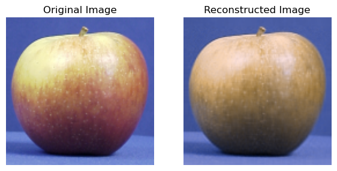

```python
# Evaluate results
# Compute residual tensor
tensor_res = residual_tensor(tensorAppletop, tensor_tkdAppletop)
# Compute error of approximation
rel_error = tensor_res.frob_norm / tensorAppletop.frob_norm
print("Relative error of approximation for Car tensor = {}".format(rel_error))

# Reconstruction
tensor_recAppletop = tensor_tkdAppletop.reconstruct()
# Plot original and reconstructed images side by side
plot_tensors(tensorAppletop, tensor_recAppletop)


# Compute residual tensor
tensor_res = residual_tensor(tensorAppleside, tensor_tkdAppleside)
# Compute error of approximation
rel_error = tensor_res.frob_norm / tensorAppleside.frob_norm
print("Relative error of approximation for Apple tensor = {}".format(rel_error))
# Reconstruction
tensor_recAppleside = tensor_tkdAppleside.reconstruct()
# Plot original and reconstructed images side by side
plot_tensors(tensorAppleside, tensor_recAppleside)
plt.show()
```

Reducing the multiplinear rank $R_3$ in the core tensor $G$ to 2 results in 2 dimensions to represent the information for colour. Hence the Tucker decomposition choses two of the most important colours used to represent the image. In this case of the side of the apple, red is more dominant than green so green is greatly attenuated. The reconstructed apple is presented in the shades of red/brown.

### Solution: Part 3

```
Relative error of approximation for Car tensor = 0.19283105301446624
Relative error of approximation for Apple tensor = 0.22511914105500552
```

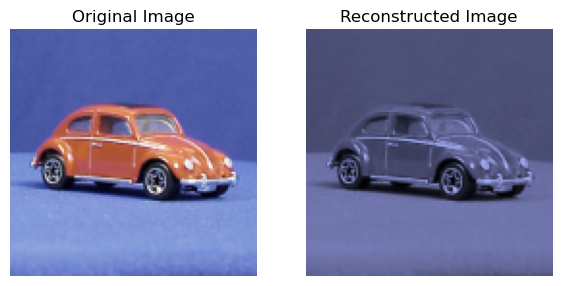

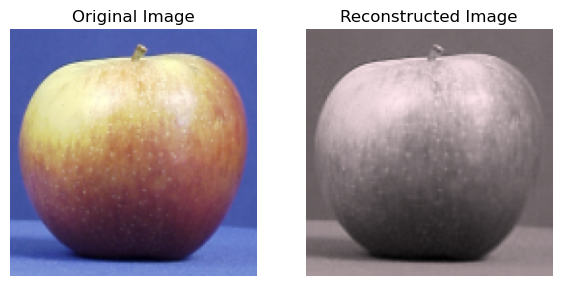

```python
# Create tensors from images
# car
car = get_image(item="car", view="side")
tensorCar = Tensor(car)
# apple
apple =  get_image(item="apple",view="side")
tensorApple = Tensor(apple)

# Perform decomposition
algorithm = HOSVD()
tensor_tkdCar = algorithm.decompose(tensorCar, rank=(50, 50, 1))

algorithm = HOSVD()
tensor_tkdApple = algorithm.decompose(tensorApple, rank=(50, 50, 1))

# Evaluate results
# Compute residual tensor
tensor_res = residual_tensor(tensorCar, tensor_tkdCar)
# Compute error of approximation
rel_error = tensor_res.frob_norm / tensorCar.frob_norm
print("Relative error of approximation for Car tensor = {}".format(rel_error))

# Reconstruction
tensor_recCar = tensor_tkdCar.reconstruct()
# Plot original and reconstructed images side by side
plot_tensors(tensorCar, tensor_recCar)


# Compute residual tensor
tensor_res = residual_tensor(tensorApple, tensor_tkdApple)
# Compute error of approximation
rel_error = tensor_res.frob_norm / tensorApple.frob_norm
print("Relative error of approximation for Apple tensor = {}".format(rel_error))
# Reconstruction
tensor_recApple = tensor_tkdApple.reconstruct()
# Plot original and reconstructed images side by side
plot_tensors(tensorApple, tensor_recApple)
plt.show()
```

Reducing the multiplinear rank $R_3$ in the core tensor $G$ to 1 results in 1 dimension to represent the information for colour (i.e. it is a monochrome). Hence the Tucker decomposition choses the most important colour channel to represent the image in grayscale. For the car, the red and blue colours are reasonably balanced, so the inensity level between the car and background is not contrasted. For the apple, red is slightly more dominant than the background colour blue, hence the outline of the apple is made out more clearly.